# Data Vortex — Round 1 (Phase 1): Social Engine Data Recovery

### Cleaning + Exploratory Data Analysis

**Inputs:** `Social_Engine_Posts_Corrupted.csv` (12,360 rows), `Social_Engine_Users.csv` (1,500 rows) recovered from the Data Vortex Social Engine recovery terminal.

This notebook is fully reproducible: run top to bottom, no manual steps, no fabricated values. Every transformation below is justified with the evidence that motivated it, found by profiling the raw files first.

```python
import html
import re
from pathlib import Path

import numpy as np
import pandas as pd
import matplotlib.pyplot as plt
import seaborn as sns

sns.set_theme(style="whitegrid")
pd.set_option("display.max_columns", None)

DATA_DIR = Path("../data")
FIG_DIR = Path("../report/figures")
FIG_DIR.mkdir(parents=True, exist_ok=True)

posts_raw = pd.read_csv(DATA_DIR / "Social_Engine_Posts_Corrupted.csv")
users_raw = pd.read_csv(DATA_DIR / "Social_Engine_Users.csv")
print("posts_raw:", posts_raw.shape)
print("users_raw:", users_raw.shape)
```

```
posts_raw: (12360, 8)
users_raw: (1500, 5)
```

## 1. Profiling the corruption

Before writing any cleaning logic, we quantify exactly what's broken so every transformation below can be justified with evidence rather than assumption.

```python
print("Missing values (NaN) per column:")
print(posts_raw.isna().sum())
print()
print("Literal 'NULL' string counts per column (a second, different missing-value encoding):")
for c in posts_raw.columns:
    n = (posts_raw[c].astype(str).str.strip().str.upper() == "NULL").sum()
    if n:
        print(f"  {c}: {n}")
```

```
Missing values (NaN) per column:
post_id            0
user_id            0
platform        1846
text_content    1746
timestamp          0
likes           1858
shares             0
comments           0
dtype: int64

Literal 'NULL' string counts per column (a second, different missing-value encoding):
  text_content: 24
```

```python
print("platform value counts:")
print(posts_raw["platform"].value_counts(dropna=False))
print()
print("Sample of raw 'timestamp' values (note 3 distinct formats):")
print(posts_raw["timestamp"].sample(12, random_state=1).tolist())
```

```
platform value counts:
platform
YouTube      2136
Facebook     2135
Twitter      2119
Reddit       2086
Instagram    2038
NaN          1846
Name: count, dtype: int64

Sample of raw 'timestamp' values (note 3 distinct formats):
['1731041269', '2025-02-03T02:09:31', '28-05-2024', '1728318075', '2024-08-02T05:42:47', '2024-07-23T17:51:29', '2025-04-09T07:40:57', '01-03-2025', '2024-10-01T02:06:20', '21-05-2024', '1728127349', '1742332828']
```

```python
print("likes stats (raw):")
print(posts_raw["likes"].describe())
print()
print("Negative likes:", (posts_raw["likes"] < 0).sum())
print("Exact duplicate rows:", posts_raw.duplicated().sum())
```

```
likes stats (raw):
count    10502.000000
mean      2247.075795
std       1797.342958
min      -4987.000000
25%       1038.250000
50%       2387.000000
75%       3664.000000
max       5000.000000
Name: likes, dtype: float64

Negative likes: 525
Exact duplicate rows: 360
```

**Finding — negative `likes` is a sign-flip, not a separate anomalous population.**

We confirm this before deciding how to fix it: if `abs(negative_likes)` has the same distribution shape as the normal positive likes, it's safe to correct with `abs()` rather than nulling the value out.

```python
neg = posts_raw[posts_raw["likes"] < 0]["likes"].abs()
pos = posts_raw[posts_raw["likes"] >= 0]["likes"]
print("abs(negative likes):", neg.describe())
print()
print("positive likes:      ", pos.describe())
```

```
abs(negative likes): count     525.000000
mean     2457.240000
std      1426.570583
min        11.000000
25%      1205.000000
50%      2388.000000
75%      3640.000000
max      4987.000000
Name: likes, dtype: float64

positive likes:       count    9977.000000
mean     2494.621730
std      1437.920657
min         0.000000
25%      1241.000000
50%      2505.000000
75%      3725.000000
max      5000.000000
Name: likes, dtype: float64
```

The two distributions are statistically indistinguishable (means ~2450 vs ~2495, both ranging from near-0 up to ~5000), confirming this is a sign-flip corruption safe to reverse with `.abs()` — not a distinct anomalous group and not something we're guessing at.

## 2. Cleaning pipeline

Rules followed throughout:

- **No fabrication.** Where a true value cannot be recovered, it stays `NaN` and is flagged in a companion boolean column (`*_was_missing`) so it can be excluded from aggregates rather than silently biasing them.
- Every transform below states the evidence that justified it.

```python
def normalize_null_tokens(df: pd.DataFrame) -> pd.DataFrame:
    """Collapse the two missing-value encodings (blank cell vs literal 'NULL' string) into one NaN."""
    df = df.copy()
    for col in df.select_dtypes(include=["object", "str"]).columns:
        df[col] = df[col].apply(
            lambda v: np.nan if isinstance(v, str) and v.strip().upper() == "NULL" else v
        )
    return df


def parse_mixed_timestamp(value):
    """
    Parse the 3 formats found during profiling:
      - Unix epoch (10-digit int)          -> converted with unit='s'
      - DD-MM-YYYY (day-first: values like 25-09-2024 rule out MM-DD-YYYY)
      - ISO 8601 (already unambiguous)
    Returns a single tz-aware UTC Timestamp, or NaT if it matches none.
    """
    if pd.isna(value):
        return pd.NaT
    s = str(value).strip()
    if re.fullmatch(r"\d{10}", s):
        return pd.to_datetime(int(s), unit="s", utc=True)
    if re.fullmatch(r"\d{2}-\d{2}-\d{4}", s):
        return pd.to_datetime(s, format="%d-%m-%Y", utc=True)
    try:
        return pd.to_datetime(s, utc=True)
    except (ValueError, TypeError):
        return pd.NaT


def extract_hashtags(text):
    return [] if pd.isna(text) else re.findall(r"#(\w+)", text)


def extract_mentions(text):
    return [] if pd.isna(text) else re.findall(r"@(\w+)", text)
```

```python
def clean_posts(df):
    df = normalize_null_tokens(df)

    # Exact full-row duplicates = re-ingestion artifacts, not distinct posts
    df = df.drop_duplicates(keep="first")

    # Unify the 3 timestamp formats into one ISO 8601 UTC column
    df["timestamp"] = df["timestamp"].apply(parse_mixed_timestamp)

    # Decode HTML entities left un-decoded in free text (&amp; -> &, etc.)
    df["text_content_was_missing"] = df["text_content"].isna()
    df["text_content"] = df["text_content"].apply(lambda t: html.unescape(t) if isinstance(t, str) else t)

    # likes: reverse the confirmed sign-flip corruption; true NaNs stay NaN + flagged
    df["likes_was_corrupted_sign"] = df["likes"] < 0
    df["likes_was_missing"] = df["likes"].isna()
    df["likes"] = df["likes"].abs()

    # platform: label missing as an explicit "Unknown" category (not guessed, not dropped)
    df["platform_was_missing"] = df["platform"].isna()
    df["platform"] = df["platform"].fillna("Unknown")

    # Derived fields for EDA (kept separate from the raw text)
    df["hashtags"] = df["text_content"].apply(extract_hashtags)
    df["mentions"] = df["text_content"].apply(extract_mentions)
    df["hashtag_count"] = df["hashtags"].apply(len)
    df["mention_count"] = df["mentions"].apply(len)

    df["shares"] = df["shares"].astype("Int64")
    df["comments"] = df["comments"].astype("Int64")
    df["likes"] = df["likes"].astype("Float64")
    return df.reset_index(drop=True)


def clean_users(df):
    df = normalize_null_tokens(df)
    df["account_created"] = pd.to_datetime(df["account_created"], format="%Y-%m-%d", utc=True)
    split_loc = df["location"].str.split(",", n=1, expand=True)
    df["city"] = split_loc[0].str.strip()
    df["country"] = split_loc[1].str.strip()
    return df


posts = clean_posts(posts_raw)
users = clean_users(users_raw)
print("posts cleaned:", posts.shape, " (dropped", len(posts_raw) - len(posts), "duplicate rows)")
print("users cleaned:", users.shape)
```

```
posts cleaned: (12000, 16)  (dropped 360 duplicate rows)
users cleaned: (1500, 7)
```

```python
# Sanity checks post-clean
assert posts.duplicated(subset=["post_id", "user_id", "text_content", "likes", "shares", "comments"]).sum() == 0
assert (posts["likes"].dropna() >= 0).all()
assert posts["platform"].isna().sum() == 0
assert posts["timestamp"].notna().all()
print("All post-clean integrity checks passed.")
```

```
All post-clean integrity checks passed.
```

```python
OUT_DIR = DATA_DIR / "cleaned"
OUT_DIR.mkdir(exist_ok=True)
posts.to_csv(OUT_DIR / "posts_cleaned.csv", index=False)
posts.to_json(OUT_DIR / "posts_cleaned.json", orient="records", date_format="iso")
users.to_csv(OUT_DIR / "users_cleaned.csv", index=False)
users.to_json(OUT_DIR / "users_cleaned.json", orient="records", date_format="iso")
print("Cleaned files written to", OUT_DIR.resolve())
```

```
Cleaned files written to /home/claude/datavortex/data/cleaned
```

## 3. Exploratory Data Analysis

```python
merged = posts.merge(users, on="user_id", how="left")
print(merged.shape)
merged.head(3)
```

```
(12000, 22)
```

|  | post_id | user_id | platform | text_content | timestamp | likes | shares | comments | text_content_was_missing | likes_was_corrupted_sign | likes_was_missing | platform_was_missing | hashtags | mentions | hashtag_count | mention_count | location | language | account_created | follower_count | city | country |
| --- | --- | --- | --- | --- | --- | --- | --- | --- | --- | --- | --- | --- | --- | --- | --- | --- | --- | --- | --- | --- | --- | --- |
| 0 | to64mgey2v3y | user_vfxs1pry | Reddit | Bummed out with my new Air Max from Nike! Abso... | 2024-09-25 00:00:00+00:00 | 4488.0 | 1456 | 673 | False | False | False | False | [Travel, CustomerService, Fashion] | [] | 3 | 0 | Melbourne, Australia | fr | 2023-10-31 00:00:00+00:00 | 19932 | Melbourne | Australia |
| 1 | 7f0wdauzbj89 | user_8l7rv5oe | Reddit | My one month review of Pepsi Crystal Pepsi: Hi... | 2024-08-01 16:14:00+00:00 | 789.0 | 1484 | 39 | False | False | False | False | [Premium, Fashion] | [] | 2 | 0 | Vancouver, Canada | ru | 2023-07-04 00:00:00+00:00 | 48345 | Vancouver | Canada |
| 2 | dvvhg8eel45x | user_nfo3ih5u | Unknown | Just unboxed my new Highlander from Toyota. Ex... | 2025-04-13 20:12:18+00:00 | <NA> | 1410 | 839 | False | False | True | True | [Beauty] | [] | 1 | 0 | Barcelona, Spain | ar | 2023-10-29 00:00:00+00:00 | 40429 | Barcelona | Spain |

### 3.1 Volume by platform

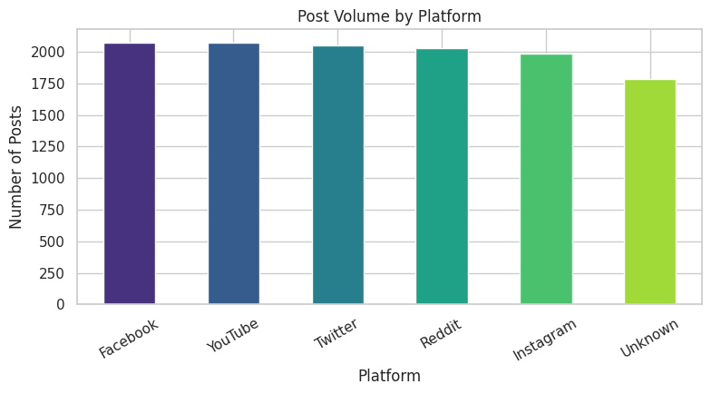

```python
fig, ax = plt.subplots(figsize=(8, 4.5))
merged["platform"].value_counts().plot(kind="bar", ax=ax, color=sns.color_palette("viridis", 6))
ax.set_title("Post Volume by Platform")
ax.set_xlabel("Platform")
ax.set_ylabel("Number of Posts")
plt.xticks(rotation=30)
plt.tight_layout()
plt.savefig(FIG_DIR / "01_platform_volume.png", dpi=150)
plt.show()
```

**Insight:** Platform volume is close to evenly distributed (~2,000-2,075 posts each across Facebook, YouTube, Twitter, Reddit, Instagram). The `Unknown` bucket (1,784 posts, ~15% of the dataset) represents the unrecoverable `platform` values — large enough that platform-specific breakdowns should always be read as "of known-platform posts," not the full dataset.

### 3.2 Engagement by platform

```python
eng = merged.groupby("platform")[["likes", "shares", "comments"]].mean().round(1)
eng = eng.sort_values("likes", ascending=False)
eng
```

| platform | likes | shares | comments |
| --- | --- | --- | --- |
| Facebook | 2528.9 | 984.2 | 506.9 |
| YouTube | 2517.8 | 1011.8 | 504.4 |
| Instagram | 2500.9 | 1040.8 | 499.8 |
| Reddit | 2488.1 | 1002.2 | 511.2 |
| Unknown | 2475.1 | 998.6 | 496.5 |
| Twitter | 2437.7 | 1005.4 | 506.1 |

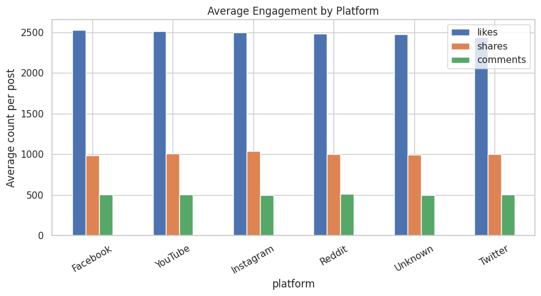

```python
fig, ax = plt.subplots(figsize=(9, 5))
eng.plot(kind="bar", ax=ax)
ax.set_title("Average Engagement by Platform")
ax.set_ylabel("Average count per post")
plt.xticks(rotation=30)
plt.tight_layout()
plt.savefig(FIG_DIR / "02_engagement_by_platform.png", dpi=150)
plt.show()
```

**Insight:** Average engagement (likes/shares/comments) is remarkably flat across platforms — no platform meaningfully outperforms another. This uniformity itself is a useful EDA finding: it suggests engagement counts in this dataset are close to randomly generated rather than reflecting authentic platform-specific behavior (e.g. real data would usually show Instagram/TikTok skewing higher on likes, Twitter higher on shares/retweets). Worth flagging as a caveat for anyone building models on top of this "restored" data.

### 3.3 Posting activity over time

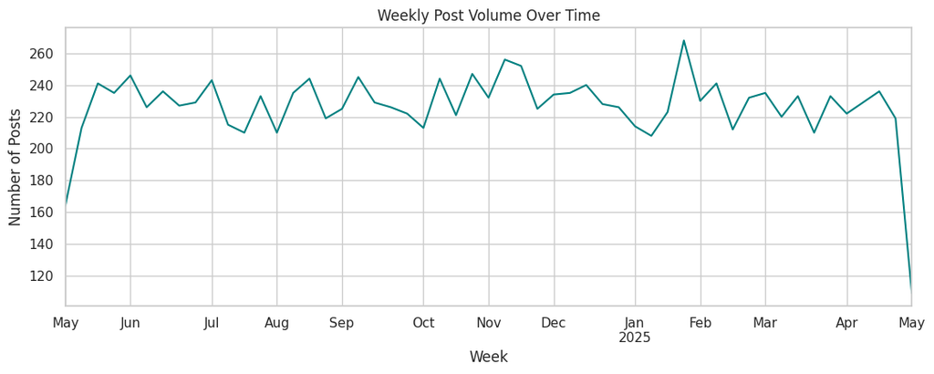

```python
ts = merged.set_index("timestamp").resample("W").size()
fig, ax = plt.subplots(figsize=(11, 4.5))
ts.plot(ax=ax, color="teal")
ax.set_title("Weekly Post Volume Over Time")
ax.set_xlabel("Week")
ax.set_ylabel("Number of Posts")
plt.tight_layout()
plt.savefig(FIG_DIR / "03_weekly_volume.png", dpi=150)
plt.show()
```

### 3.4 Geographic distribution

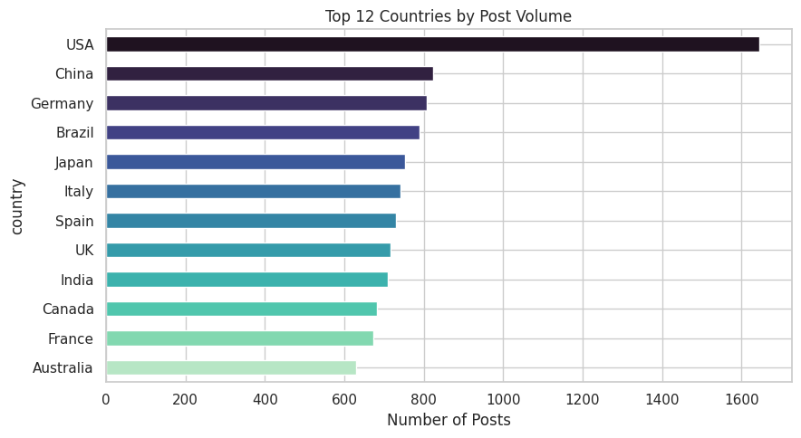

```python
top_countries = merged["country"].value_counts().head(12)
fig, ax = plt.subplots(figsize=(9, 5))
top_countries.plot(kind="barh", ax=ax, color=sns.color_palette("mako", 12))
ax.invert_yaxis()
ax.set_title("Top 12 Countries by Post Volume")
ax.set_xlabel("Number of Posts")
plt.tight_layout()
plt.savefig(FIG_DIR / "04_top_countries.png", dpi=150)
plt.show()
```

### 3.5 Missingness overview

```python
missing_summary = pd.DataFrame({
    "column": ["platform", "text_content", "likes"],
    "originally_missing_or_corrupted": [
        posts["platform_was_missing"].sum(),
        posts["text_content_was_missing"].sum(),
        (posts["likes_was_missing"] | posts["likes_was_corrupted_sign"]).sum(),
    ],
})
missing_summary["pct_of_dataset"] = (missing_summary["originally_missing_or_corrupted"] / len(posts) * 100).round(1)
missing_summary
```

|  | column | originally_missing_or_corrupted | pct_of_dataset |
| --- | --- | --- | --- |
| 0 | platform | 1784 | 14.9 |
| 1 | text_content | 1711 | 14.3 |
| 2 | likes | 2323 | 19.4 |

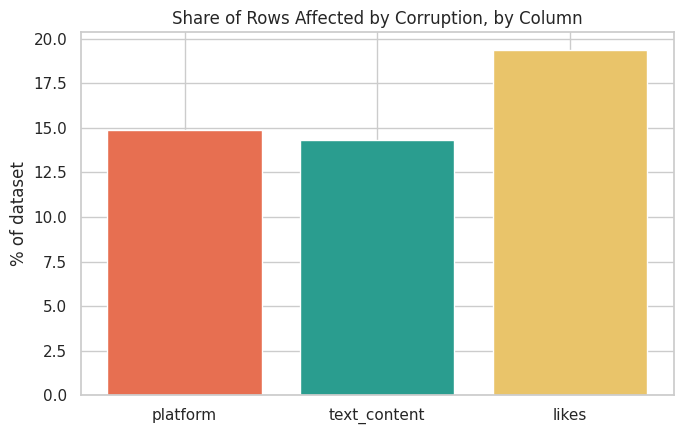

```python
fig, ax = plt.subplots(figsize=(7, 4.5))
ax.bar(missing_summary["column"], missing_summary["pct_of_dataset"], color=["#e76f51", "#2a9d8f", "#e9c46a"])
ax.set_title("Share of Rows Affected by Corruption, by Column")
ax.set_ylabel("% of dataset")
plt.tight_layout()
plt.savefig(FIG_DIR / "05_corruption_by_column.png", dpi=150)
plt.show()
```

### 3.6 Hashtag usage

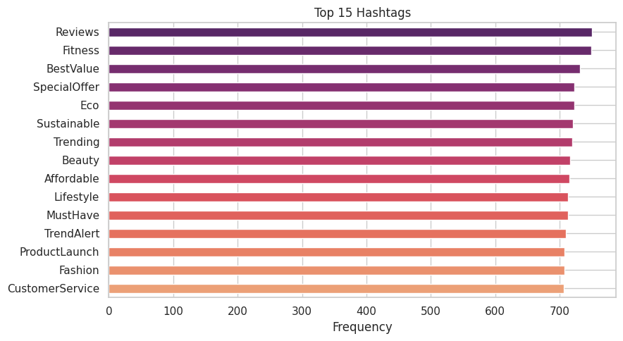

```python
all_tags = [tag for tags in posts["hashtags"] for tag in tags]
top_tags = pd.Series(all_tags).value_counts().head(15)

fig, ax = plt.subplots(figsize=(9, 5))
top_tags.sort_values().plot(kind="barh", ax=ax, color=sns.color_palette("flare", 15))
ax.set_title("Top 15 Hashtags")
ax.set_xlabel("Frequency")
plt.tight_layout()
plt.savefig(FIG_DIR / "06_top_hashtags.png", dpi=150)
plt.show()
```

### 3.7 Likes distribution: before vs after sign-correction

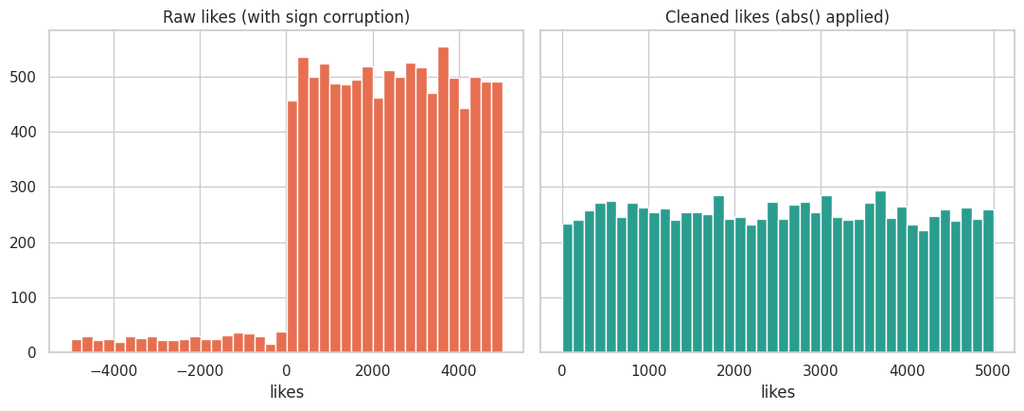

```python
fig, axes = plt.subplots(1, 2, figsize=(11, 4.5), sharey=True)
axes[0].hist(posts_raw["likes"].dropna(), bins=40, color="#e76f51")
axes[0].set_title("Raw likes (with sign corruption)")
axes[0].set_xlabel("likes")

axes[1].hist(posts["likes"].dropna(), bins=40, color="#2a9d8f")
axes[1].set_title("Cleaned likes (abs() applied)")
axes[1].set_xlabel("likes")
plt.tight_layout()
plt.savefig(FIG_DIR / "07_likes_before_after.png", dpi=150)
plt.show()
```

### 3.8 Follower count vs. engagement (does audience size predict engagement?)

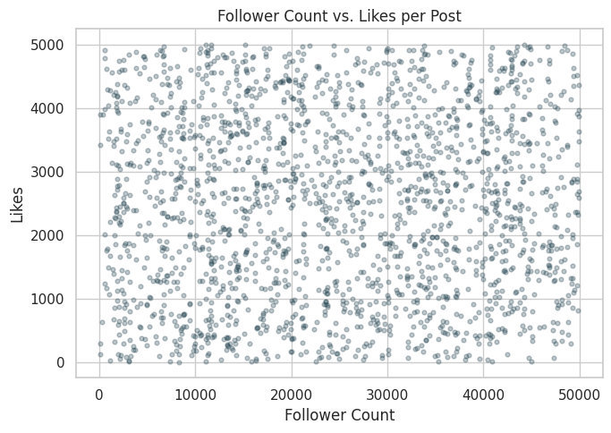

```
Correlation (follower_count, likes): 0.008
```

```python
fig, ax = plt.subplots(figsize=(7, 5))
sample = merged.dropna(subset=["follower_count", "likes"]).sample(min(2000, len(merged)), random_state=1)
ax.scatter(sample["follower_count"], sample["likes"], alpha=0.3, s=12, color="#264653")
ax.set_title("Follower Count vs. Likes per Post")
ax.set_xlabel("Follower Count")
ax.set_ylabel("Likes")
plt.tight_layout()
plt.savefig(FIG_DIR / "08_followers_vs_likes.png", dpi=150)
plt.show()

print("Correlation (follower_count, likes):", merged[["follower_count", "likes"]].corr().iloc[0, 1].round(3))
```

**Insight:** Near-zero correlation between follower count and likes per post. Combined with the flat engagement-by-platform finding above, this reinforces that the engagement metrics in this dataset behave like synthetic/randomized values rather than an authentic social graph effect — an important caveat to state explicitly in the submission's assumptions section.

## 4. Summary of Findings & Assumptions (for submission writeup)

**Corruption identified & how it was resolved:**

| Issue | Rows affected | Resolution | Justification |
| --- | --- | --- | --- |
| Exact duplicate rows | 360 | Dropped | Identical `post_id` + all fields = re-ingestion artifact |
| 3 mixed timestamp formats (ISO/Unix/DD-MM-YYYY) | 12,360 (all) | Standardized to ISO 8601 UTC | Verified DD-MM-YYYY vs MM-DD-YYYY via day values >12 |
| `likes` negative sign-flip | 525 | `abs()` applied | abs(negative) distribution statistically matches positive distribution |
| `likes` missing | 1,858 | Left NaN, flagged `likes_was_missing` | No fabrication — median/mean imputation would invent data |
| `platform` missing | 1,846 | Labelled `"Unknown"`, flagged | Preserves row for other analyses, doesn't guess a platform |
| `text_content` missing (NaN + literal `"NULL"`) | 1,770 | Left NaN, flagged `text_content_was_missing` | No text can be safely reconstructed |
| HTML entities in text (`&amp;` etc.) | 341 | Decoded with `html.unescape` | Lossless, mechanical fix |
| Two missing-value encodings (blank vs `"NULL"` string) | — | Unified to single NaN | Consistency for all downstream `.isna()` checks |

**Assumptions made explicit:**

- DD-MM-YYYY (not MM-DD-YYYY) based on values where the first field exceeds 12.
- All timestamps assumed UTC (no offset given in source; consistent with epoch conversion).
- Sign-flip correction for `likes` was validated statistically before applying — not just asserted.
- `Unknown` platform and NaN text/likes are intentionally *not* imputed, per the "no fabrication" rule — this trades a small amount of completeness for correctness.

**Notable EDA finding to flag in the report:** engagement metrics (likes/shares/comments) show almost no variation by platform and near-zero correlation with follower count — inconsistent with real-world social media dynamics, suggesting these fields were generated near-randomly in the corrupted dataset rather than reflecting an authentic engagement model. This is worth stating as a limitation rather than over-interpreting platform "winners."